# Community Challenge primeur

Hieronder werk ik de allereerste Community Challenge uit. Om te beginnen importeer ik een paar modules die nodig zijn om het csv bestand te openen. Hierin staan een aantal ratings van opdrachten. Onderzocht worden:

- Totaal aantal ratings
- Aantal ratings per opdracht
- Gemiddelde rating per opdracht en welke een lagere rating hebben dan 3
- Of de herziening van de opdracht Flex met boxen heeft geleid tot een beter rating De conclusie luidt dat dit inderdaag het geval is.

```python
import numpy as np
import pandas as pd

df = pd.read_csv("ratings.csv")
df.head()
```

|  | exercise | first_name | last_name | rating | date |
| --- | --- | --- | --- | --- | --- |
| 0 | Flex met boxen | Fergus | Crowther | 5 | 2021-10-29 |
| 1 | Commandline commands | Monica | Bartaloni | 5 | 2021-01-05 |
| 2 | Read that data | Prissie | Prangle | 5 | 2021-10-26 |
| 3 | Maak een kattenwebsite | Florida | Ambrogiotti | 3 | 2021-07-17 |
| 4 | Maak een kattenwebsite | Sherrie | Hadfield | 4 | 2021-10-21 |

## Aantal ratings:

Hieronder zie je dat er 1000 opdrachten zijn geratet.

```python
df.count(axis=0)
```

```
exercise      1000
first_name    1000
last_name     1000
rating        1000
date          1000
dtype: int64
```

## Aantal ratings per opdracht

```python
df['exercise'].value_counts()
```

```
Hover kan je gaan         216
Read that data            204
Maak een kattenwebsite    198
Flex met boxen            193
Commandline commands      189
Name: exercise, dtype: int64
```

## Gemiddelde rating per opdracht

*Maak een kattenwebsite* en *Read that data* hebben een lagere rating dan 3.

```python
df.groupby("exercise").rating.mean()
```

```
exercise
Commandline commands      3.116402
Flex met boxen            3.704663
Hover kan je gaan         3.023148
Maak een kattenwebsite    2.989899
Read that data            2.921569
Name: rating, dtype: float64
```

## Op 1 mei 2021 is de opdracht *Flex met boxen* herzien. De rating is sindsdien verhoogd van 2.8 naar 4.4.

```python
# Bepaal hoogste en laagste data waarbinnen gemeten is.
df['date'].max(axis=0), df['date'].min(axis=0)
```

```
('2021-12-02', '2020-12-01')
```

```python
# voor herziening
df['date'] = pd.to_datetime(df['date'])
subset = df[df["exercise"]=="Flex met boxen"]
start_date = '2020-12-01'
end_date =  '2021-5-1'
mask = (subset['date'] >= start_date) & (subset['date'] < end_date)
subset_voor = subset.loc[mask]
subset_voor.rating.mean()
```

```
2.776470588235294
```

```python
# na herziening
subset2 = df[df["exercise"]=="Flex met boxen"]
start_date = '2021-5-1'
end_date =  '2021-12-3'
mask = (subset2['date'] >= start_date) & (subset2['date'] < end_date)
subset2_na = subset2.loc[mask]
subset2_na.rating.mean()
```

```
4.435185185185185
```

```
(array([[<AxesSubplot:title={'center':'rating'}>]], dtype=object),
 array([[<AxesSubplot:title={'center':'rating'}>]], dtype=object))
```

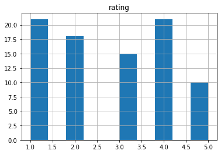

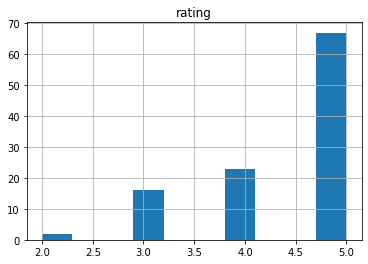

```python
subset_voor.hist(column="rating"), subset2_na.hist(column="rating")
```